# EDA for Traffic Announcements

## Table of Contents

## Preprocessing

- This dataset contains set of traffic announcements entered into the system by the Transport Management Center operators from **2018** to **2020** which are stored in **2** different datasets.
- There are **12** variables, with using Rbind **58,422** observations are obtained.
- We converted Turkish variables and some records into English.
- We transformed **Announcement Type** and **Accident Type** variables into factorized variables.
- We filtered out some 2020 observations, where we calculated the problem index, because of the change in date and time structure but kept them in count operations.

## Identifying Most Problematic Announcement Type

```
##            Announcement_Types Avg_Problem_Index CountAnnouncement SumIndex
## 5         Infrastructure Work             90.64                67  6072.77
## 4      Construction Work-Road             59.91                41  2456.44
## 6 Construction Work-Structure             26.44                17   449.56
## 2                 Maintenance             11.83              5290 62577.05
## 3                 Landscaping              5.18               505  2616.53
## 1       Accident Notification              0.91             26250 23794.24
```

- **Problem Index = Duration x Effected Lanes**
- On average, the most problematic announcement type was the **Infrastructure Work**.
- In total, **maintenance** and **accident notification** made much more traffic since they occurred more frequently.

## Identifying Most Problematic Announcement Type

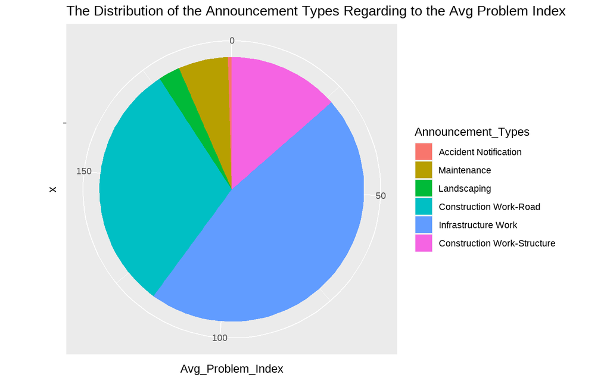

## Identifying Most Problematic Five Locations

```
##                                             Location Problem_Index
## 11553                   S.Yolu Z.Burnu-Bakırköy yönü      23801.00
## 1347    Tünel Vecdi Diker Altunizade - Ümraniye yönü      18630.00
## 5030                        D100 Kınalı-Silivri Yönü      13202.00
## 6734  D100 Kadıköy-Çamlıca D100 Çamlıca-Kadıköy Yönü      13069.77
## 3687         Şile Yolu Tepeüstü-Ümraniye Kavşak Yönü      10921.15
```

## Identifying Most Problematic Five Locations on the Map

[interactive chart not shown]

## Relationship Between the 2019 Election and Running Projects

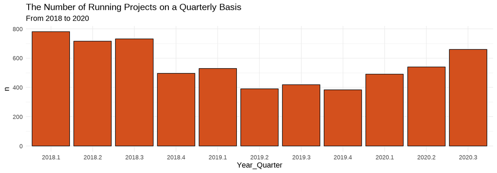

- The first round of the election: March 2019
- The second round of the election: June 2019
- Filtered announcement types are; Landscaping, Maintenance, Infrastructure Work, Construction Work-Structure, Construction Work-Road.

## Effect of the Pandemic on the Number of Accidents

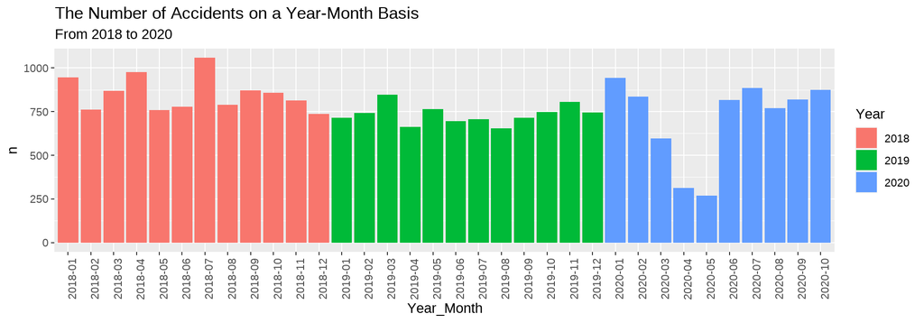

- The first pandemic case occurred in March.
- In April and May, there were a lot of lockdowns were applied.

## Daily Number of the Accidents (2018-07)

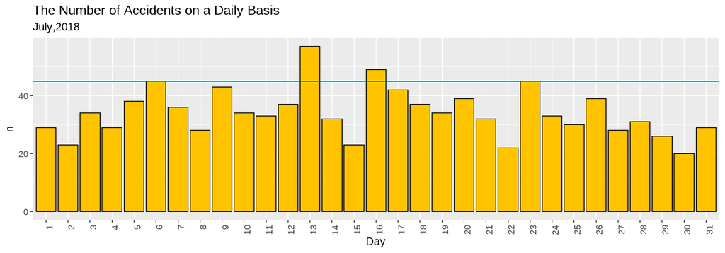

- 15’th of July is a national holiday in Turkey.

## Distribution of the Announcement Types During Holidays

**Holiday event calendar is introduced to the dataset.**

During Holiday;

- Accident and vehicle breakdown reasons were the majority of announcements.
- The municipality may prefer to work on maintenance works.

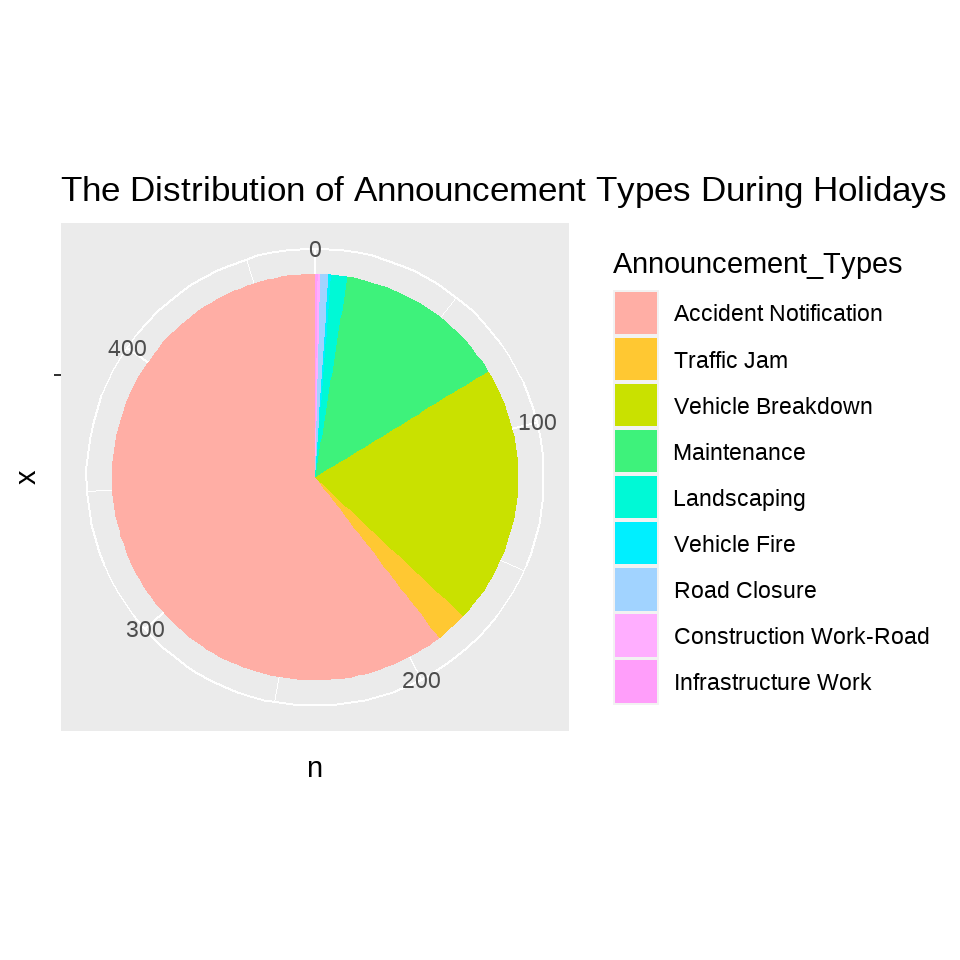

## Conclusions

- According to our problem index, infrastructure work & construction work-road were the worst traffic makers.
- Maintenance & Accident Notification occurred more frequently, with this aspect, these were the worst for the traffic.
- Considering that there was an election in March 2019, the number of projects carried out compared to the last quarter of the previous year has increased.
- With the new administration and the elimination of election uncertainty, the number of projects carried out by the municipality has started to increase regularly from the last quarter of 2019.
- The number of accidents significantly decreased during the pandemic.
- After rule bendings, the number of accidents increased to the standard levels.
- During holidays, accident & vehicle breakdown notifications composed about 80% of the total notifications.

## References

- [Data Source - İBB Open Data Portal](https://data.ibb.gov.tr/dataset/ulasim-yonetim-merkezi-uym-tarafindan-sisteme-girilen-trafik-duyurulari)
- [External Data Source - Holiday Events](https://www.tatilsepeti.com/resmi-tatil-gunleri)
- [Mapping Link](https://medium.com/@joyplumeri/how-to-make-interactive-maps-in-r-shiny-brief-tutorial-c2e1ef0447da)

*You may click* [here](https://pjournal.github.io/mef04g-a-k-a-r/) *to reach other items of A.K.A - R Group’s Progress Journal.*